# IMPACT Engine: knowledge base

NSF Regional Innovation Engines, Cohort 2. Technology profile v3.1. Draft, in progress

**NSF IMPACT Engine in Indiana**, led by Indiana University. NSF award 2532359, start August 2026. Search window for papers and patents: from August 2021 (five years before the award) onward.

## At a glance

| Measure | Value |
| --- | --- |
| People named by NSF or the Engine’s site | 5 |
| of them active researchers (>= 5 works since window start) | 3 |
| Team members who are inventors (2021-2025 grants, in the region) | 1 |
| Partners (site list + team members’ organisations) | 1 |
| Knowledge-producer partners (universities, labs, institutes) | 0 |
| Partner papers in the Engine’s topics | 0 |
| of them with an in-region partner | 0 |
| Regional patents in the technology profile (2021-2025 grants) | 1001 |
| Location quotient of the technology profile (patents) | 1.47 |
| Share of regional technology patents owned by partners | 0.0% |

## Economic base

| NAICS | Industry | Employment in region | Establishments | Share of US employment | Employment LQ |
| --- | --- | --- | --- | --- | --- |
| 3391 | Medical equipment and supplies manufacturing (incl. orthopedic devices) | 18,313 | 215 | 5.9% | 2.84 |
| 3254 | Pharmaceutical and medicine manufacturing | 13,799 | 35 | 4.3% | 2.05 |
| 6215 | Medical and diagnostic laboratories | 6,031 | 412 | 1.8% | 0.87 |

Industries related to the Engine’s technology (chosen from the NSF abstract, see `data/manual/engine_naics.csv`). County Business Patterns 2023; LQ = the industry’s share of regional employment relative to its share of US employment (1 = US average). Region: whole state(s).

## Technology profile

Version 3.1, core. The NSF abstract names 5 technologies of this Engine (scientific and technical fragments extracted with a fixed prompt; the extraction was done by hand in a chat session, not reproducible). For each technology, all 4,516 OpenAlex topics and all CPC main groups are ranked by several independent signals; the core keeps up to 2 topics and 2 CPC main groups per technology. *Judge*: chosen by a rubric judge where no candidate was confirmed by two kinds of evidence (also by hand in a chat session). An empty cell: no suitable item among the candidates. See Methodology and the comparison of versions.

| # | Technology | OpenAlex topics | CPC main groups |
| --- | --- | --- | --- |
| 1 | musculoskeletal injury or disease | T13946 Musculoskeletal Disorders and Rehabilitation T10084 Musculoskeletal pain and rehabilitation | A61P19/00 Drugs for skeletal disorders (judge) A61B17/00 Surgical instruments, devices or methods (judge) |
| 2 | drug development and biologics | T12255 Biosimilars and Bioanalytical Methods (judge) T10211 Computational Drug Discovery Methods (judge) | A61P7/00 Drugs for disorders of the blood or the extracellular fluid A61P25/00 Drugs for disorders of the nervous system |
| 3 | diagnostic technologies |  | A61B8/00 Diagnosis using ultrasonic, sonic or infrasonic waves A61B6/00 Apparatus or devices for radiation diagnosis; Apparatus or devices for radiation diagnosis combined with radiation therapy equip… |
| 4 | multimodal health data and AI-enabled tools | T11396 Artificial Intelligence in Healthcare T13702 Machine Learning in Healthcare | G16H10/00 ICT specially adapted for the handling or processing of patient-related medical or healthcare data |
| 5 | orthopedic devices and manufacturing processes | T10512 Orthopaedic implants and arthroplasty (judge) T10059 Bone Tissue Engineering Materials (judge) | Y10S606/00 Surgery (judge) |

## People

| Role | People |
| --- | --- |
| researcher | 3 |
| organizer | 2 |

| Name | Role | On NSF award | Title | Organisation | Works since window (in Engine topics) | h-index | Patents 2021-25 (in Engine profile) | Site | OpenAlex |
| --- | --- | --- | --- | --- | --- | --- | --- | --- | --- |
| Amrou Awaysheh | researcher | Co-PI | Chief Technology & Innovation Officer | NSF IMPACT Engine | 15 (0) | 14 |  | [page](https://mskimpact.org/about.html) | [profile](https://openalex.org/A5042819663) |
| Jill Fehrenbacher | researcher | Co-PI | Chief Learning Officer | NSF IMPACT Engine | 24 (4) | 26 | 1 (1) | [page](https://mskimpact.org/about.html) | [profile](https://openalex.org/A5065178270) |
| Melissa Kacena | researcher | PI; Co-PI | Chief Scientific Officer | NSF IMPACT Engine | 82 (9) | 40 |  | [page](https://mskimpact.org/about.html) | [profile](https://openalex.org/A5034416233) |
| Jim Lancaster | organizer | PI; Co-PI | Chief Executive Officer | NSF IMPACT Engine | - | - |  | [page](https://mskimpact.org/about.html) |  |
| Ryan J Christner | organizer | Co-PI |  |  | - | - |  |  |  |

Publication counts are shown only where the OpenAlex author matches both the name and the person’s current organisation. The OpenAlex link is given only for these reliable matches, and not for profiles flagged as possibly merging several namesakes. *Site* links to the page of the Engine’s website where the person is named. Click a number of works to see the list on the Publications page. *Patents*: US grants 2021-2025 with the person among the inventors (same last and first name, address in the Engine’s states); click the number for the list on the Patents page. In brackets: works in the Engine’s topics, patents with a CPC code in the Engine’s technology profile.

## Researchers at partner organisations

No knowledge-producer partner in the Engine’s states with works in its topics.

## Partners

| Organisation class | Partners |
| --- | --- |
| company | 1 |

Partner list on the site: *Not available: partner sections render logos only (no names in the page source)*.

| Partner | Class | State | OpenAlex works since window (all topics) |
| --- | --- | --- | --- |

## Science base: partner papers in the Engine’s topics

```
## No knowledge-producer partners with an OpenAlex institution record.
```

## Technology base: patents

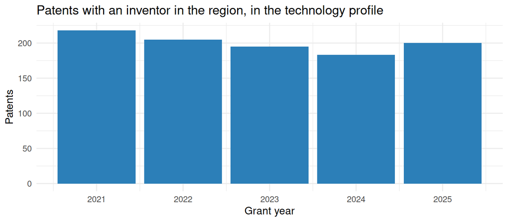

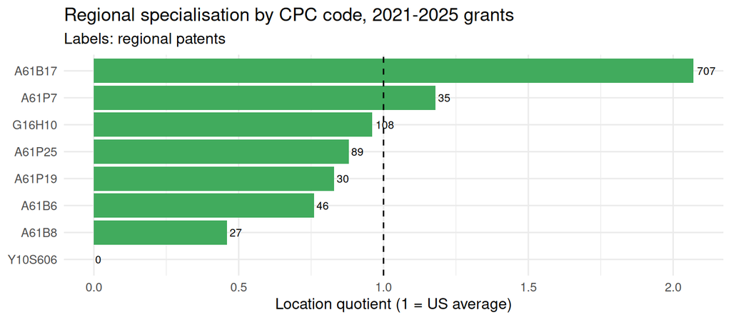

| Assignee | Regional patents in profile |
| --- | --- |
| DEPUY IRELAND UNLIMITED COMPANY | 62 |
| Biomet Manufacturing, LLC | 61 |
| Biomet Sports Medicine, LLC | 57 |
| Zimmer, Inc. | 43 |
| DePuy Synthes Products, Inc. | 41 |
| Cook Medical Technologies LLC | 27 |
| Cilag GmbH International | 26 |
| Eli Lilly and Company | 26 |
| Howmedica Osteonics Corp. | 21 |
| DEPUY SYNTHES PRODUCTS, INC. | 20 |

Partner-owned patents invented in the region: 0, of which 0 (NA) fall in the Engine’s technology profile.

## Competition

With 1001 patents in the technology profile (2021-2025 grants), the Engine’s region would rank **17** among US states; its specialisation (LQ) is 1.471.

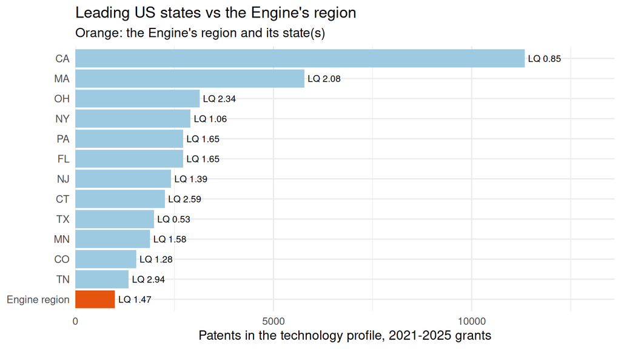

| Country | Share of US patents in profile | Share of world papers in topics |
| --- | --- | --- |
| US | 68.8% | 14.5% |
| JP | 6.8% | 2.1% |
| DE | 4.8% | 3.0% |
| CN | 4.3% | 13.1% |
| GB | 2.9% | 4.3% |
| IL | 2.8% | NA |
| CA | 2.5% | 2.0% |
| KR | 2.5% | 1.9% |
| CH | 2.4% | NA |
| FR | 2.4% | NA |

Patents: inventor countries on US grants in the profile (a patent counts for every country of its inventors). Papers: author countries of OpenAlex works in the Engine’s topics since the window start.

## Data and limitations

- People: PIs and Co-PIs from the NSF Award API; leadership listed on the Engine’s website. Roles come from titles and organisations, revised with OpenAlex evidence.
- Partners: as listed on the Engine’s website, plus organisations of team members. Some Engines publish partner logos without names.
- Region: the Engine’s counties where the list is known (NEO-SMART: 18 Northeast Ohio counties; STELLAR: 11 counties from the NSF abstract), otherwise its states (state-level proxy).
- Technology profile: v3.1 (switch versions in the header). Partner papers and regional patents depend on it: v1 uses mostly CPC subclasses, the v3.1 core uses CPC main groups, which are narrower, so it counts fewer patents and the LQ of a small region rests on few patents.
- Papers: OpenAlex; partner papers are restricted to the Engine’s OpenAlex topics.
- Patents: USPTO grants 2021-2025; inventor locations from PatentsView; pre-grant publications are not included.